# Liver Time-Series DGE — Female A–E Timecourse

Ali Amer

2026-08-03

# Setup

```r
rm(list = ls(all = TRUE))
getwd()
```

```
## [1] "/Users/aliamer/Documents/GitHub/ZebraFinch_DamageFitnessProject/LiverRNASeq/TimeSeries_DGE"
```

```r
library(edgeR)
library(limma)
library(splines)
library(ggplot2)
```

# CONFIG

```r
CONFIG <- list(
  counts_file     = "ZF_Liver_rawgene_count_matrix.csv",
  master_file     = "AHDB_Exp1_MasterSpreadSheet.csv",
  samplelist_file = "ZF_Liver_sample_list.csv",
  out_dir         = "Results/Timeseries/Liver_Female/",

  sex_levels      = "F",
  outlier_bands   = numeric(0),     # none removed yet
  expected_n      = 50,             # 10 females x 5 groups, no removals
  min_n_per_group = 9,

  ## Hours since the START of heat exposure. Control anchored at 0.
  ## EDIT heat_duration_h to the actual exposure length.
  heat_duration_h = 5,
  time_map        = NULL,           # filled below

  spline_df       = 3,              # 3 df on 5 timepoints (4 df available)
  fdr_cut         = 0.05,
  n_clusters      = 6,
  seed            = 1234
)

CONFIG$time_map <- c(
  A = 0,
  B = CONFIG$heat_duration_h,
  C = CONFIG$heat_duration_h + 2,
  D = CONFIG$heat_duration_h + 24,
  E = CONFIG$heat_duration_h + 24 * 14
)

## Labels for plots and output only — NOT used in makeContrasts (hyphens would
## be parsed as subtraction).
CONFIG$treat_labels <- c(
  A = "Control", B = "Heat", C = "Heat_2-HR_Repair",
  D = "Heat_24-HR_Repair", E = "Heat_2-WK_Repair"
)

dir.create(CONFIG$out_dir, recursive = TRUE, showWarnings = FALSE)
set.seed(CONFIG$seed)
```

# Load data and build metadata

The master spreadsheet is long-format (one row per bird per blood-draw occasion), so `ID_Band` repeats. Dropping the Baseline and Heat draw occasions leaves exactly one row per bird — a row filter, not a collapse, so no values are silently discarded.

```r
Raw_Counts           <- utils::read.csv(CONFIG$counts_file, row.names = 1,
                                        check.names = FALSE)
MasterSpreadsheet    <- utils::read.csv(CONFIG$master_file, check.names = TRUE)
ZF_Liver_sample_list <- utils::read.csv(CONFIG$samplelist_file, check.names = TRUE)

## Numeric band ID from Sample_ID (ZF_4529 -> 4529)
ZF_Liver_sample_list$ID_Band <- as.numeric(
  sub("^ZF_", "", ZF_Liver_sample_list$Sample_ID)
)
stopifnot(!anyNA(ZF_Liver_sample_list$ID_Band),
          !any(duplicated(ZF_Liver_sample_list$ID_Band)),
          !any(duplicated(ZF_Liver_sample_list$RNAseq_Sample_ID)))

## Subset master to sequenced birds, then drop the extra draw occasions.
## subset() drops NA rows silently, so confirm no bird is lost.
meta <- MasterSpreadsheet[
  MasterSpreadsheet$ID_Band %in% ZF_Liver_sample_list$ID_Band, ]
bands_before <- unique(meta$ID_Band)

meta <- subset(meta, TimePoint != "Baseline" & TimePoint != "Heat")

lost_bands <- setdiff(bands_before, meta$ID_Band)
if (length(lost_bands)) {
  stop("Birds lost by the TimePoint filter (check for NA TimePoint): ",
       paste(lost_bands, collapse = ", "))
}
stopifnot(!any(duplicated(meta$ID_Band)))

## Attach the RNAseq sample IDs
meta <- merge(meta, ZF_Liver_sample_list[, c("ID_Band", "RNAseq_Sample_ID")],
              by = "ID_Band", all.x = TRUE)
stopifnot(!anyNA(meta$RNAseq_Sample_ID))

cat("Sex values (full master):\n"); print(table(MasterSpreadsheet$Sex, useNA = "ifany"))
```

```
## Sex values (full master):
```

```
##
##   F   M
## 186  70
```

```r
cat("\nTreatment x Sex (sequenced birds, one row each):\n")
```

```
##
## Treatment x Sex (sequenced birds, one row each):
```

```r
print(table(meta$Treatment, meta$Sex, useNA = "ifany"))
```

```
##
##      F  M
##   A 10 10
##   B 10 10
##   C 10  0
##   D 10  0
##   E 10  0
```

# Check count-matrix alignment

```r
missing_cols <- setdiff(meta$RNAseq_Sample_ID, colnames(Raw_Counts))
extra_cols   <- setdiff(colnames(Raw_Counts), meta$RNAseq_Sample_ID)

cat("Count matrix columns:", ncol(Raw_Counts),
    "| Metadata rows:", nrow(meta), "\n")
```

```
## Count matrix columns: 70 | Metadata rows: 70
```

```r
cat("Count colnames (first 6):\n"); print(utils::head(colnames(Raw_Counts), 6))
```

```
## Count colnames (first 6):
```

```
## [1] "ZF_4529_D_L" "ZF_4530_D_L" "ZF_4531_D_L" "ZF_4533_D_L" "ZF_4534_D_L"
## [6] "ZF_4543_D_L"
```

```r
cat("Sample list IDs (first 6):\n")
```

```
## Sample list IDs (first 6):
```

```r
print(utils::head(ZF_Liver_sample_list$RNAseq_Sample_ID, 6))
```

```
## [1] "ZF_4529_D_L" "ZF_4554_D_L" "ZF_4620_D_L" "ZF_4715_D_L" "ZF_4739_D_L"
## [6] "ZF_4755_D_L"
```

```r
cat("\nIn metadata but NOT in counts (", length(missing_cols), "):\n", sep = "")
```

```
##
## In metadata but NOT in counts (0):
```

```r
print(missing_cols)
```

```
## character(0)
```

```r
cat("In counts but not in metadata (", length(extra_cols), "):\n", sep = "")
```

```
## In counts but not in metadata (0):
```

```r
print(extra_cols)
```

```
## character(0)
```

```r
if (length(missing_cols)) {
  stop("RNAseq_Sample_IDs absent from the count matrix (", length(missing_cols),
       "). Reconcile the naming convention in ", CONFIG$samplelist_file,
       " against colnames(Raw_Counts) — fix it on the sample-list side so one ",
       "authoritative mapping remains.")
}
```

```r
stopifnot(all(CONFIG$sex_levels %in% unique(meta$Sex)))
if (length(CONFIG$outlier_bands)) {
  stopifnot(all(CONFIG$outlier_bands %in% meta$ID_Band))
}

meta <- meta[meta$Sex %in% CONFIG$sex_levels &
             meta$Treatment %in% names(CONFIG$time_map) &
             !(meta$ID_Band %in% CONFIG$outlier_bands), ]
rownames(meta) <- meta$RNAseq_Sample_ID

counts <- Raw_Counts[, rownames(meta), drop = FALSE]
stopifnot(identical(colnames(counts), rownames(meta)))

meta$Treatment <- factor(meta$Treatment, levels = names(CONFIG$time_map))
meta$Hours     <- CONFIG$time_map[as.character(meta$Treatment)]
meta$TimeVar   <- log1p(meta$Hours)   # log-spaced: hours to weeks in one design

print(table(meta$Treatment))
```

```
##
##  A  B  C  D  E
## 10 10 10 10 10
```

```r
cat("Samples retained:", nrow(meta), "\n")
```

```
## Samples retained: 50
```

```r
stopifnot(all(table(meta$Treatment) >= CONFIG$min_n_per_group),
          nrow(meta) == CONFIG$expected_n)
```

# Filter and TMM normalize

```r
## DGEList cbinds `samples` onto its own group/lib.size/norm.factors columns,
## so guard against a name collision before it silently overwrites them.
stopifnot(!any(c("group", "lib.size", "norm.factors") %in% colnames(meta)))

dge <- edgeR::DGEList(counts = counts, samples = meta, group = meta$Treatment)
keep_genes <- edgeR::filterByExpr(dge, group = dge$samples$group)
dge <- dge[keep_genes, , keep.lib.sizes = FALSE]
dge <- edgeR::calcNormFactors(dge, method = "TMM")
cat("Genes retained:", nrow(dge), "| Samples:", ncol(dge), "\n")
```

```
## Genes retained: 17029 | Samples: 50
```

```r
logcpm <- edgeR::cpm(dge, log = TRUE, prior.count = 2)
```

# QC: PCA with candidate outliers labelled

Birds 4531 and 4817 are flagged rather than removed. Check whether they sit apart from their own treatment group before deciding.

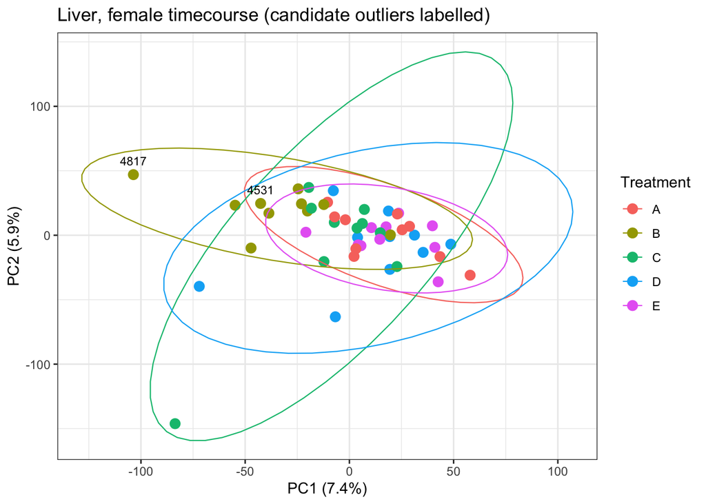

```r
pca <- stats::prcomp(t(logcpm), center = TRUE, scale. = FALSE)
n_pc <- min(5, ncol(pca$x))
pct  <- round(100 * summary(pca)$importance[2, 1:2], 1)

pca_df <- data.frame(
  PC1       = pca$x[, 1],
  PC2       = pca$x[, 2],
  Treatment = dge$samples$group,
  Band      = dge$samples$ID_Band
)
pca_df$Flag <- ifelse(pca_df$Band %in% c(4531, 4817),
                      as.character(pca_df$Band), NA_character_)

p_pca <- ggplot2::ggplot(pca_df, ggplot2::aes(PC1, PC2, colour = Treatment)) +
  ggplot2::geom_point(size = 3) +
  ggplot2::stat_ellipse(type = "norm", linewidth = 0.4, na.rm = TRUE) +
  ggplot2::geom_text(ggplot2::aes(label = Flag), colour = "black",
                     vjust = -1.1, size = 3, na.rm = TRUE) +
  ggplot2::labs(x = paste0("PC1 (", pct[1], "%)"),
                y = paste0("PC2 (", pct[2], "%)"),
                title = "Liver, female timecourse (candidate outliers labelled)") +
  ggplot2::theme_bw()
p_pca
```

```r
ggplot2::ggsave(file.path(CONFIG$out_dir, "PCA_timecourse_with_outliers.png"),
                p_pca, width = 7, height = 5, dpi = 300)
```

```r
## Distance from each sample to its own treatment-group centroid across the
## first n_pc components — a numeric companion to the visual check.
scores <- pca$x[, seq_len(n_pc), drop = FALSE]
grp    <- as.character(dge$samples$group)

centroids <- t(vapply(split(seq_len(nrow(scores)), grp),
                      function(idx) colMeans(scores[idx, , drop = FALSE]),
                      numeric(n_pc)))

d_cent <- sqrt(rowSums((scores - centroids[grp, , drop = FALSE])^2))

dist_tab <- data.frame(
  Sample    = rownames(scores),
  Band      = dge$samples$ID_Band,
  Treatment = dge$samples$group,
  DistToCentroid = round(d_cent, 2)
)
dist_tab <- dist_tab[order(-dist_tab$DistToCentroid), ]
print(utils::head(dist_tab, 10))
```

```
##                  Sample Band Treatment DistToCentroid
## ZF_4715_D_L ZF_4715_D_L 4715         C         162.42
## ZF_4817_D_L ZF_4817_D_L 4817         B         123.25
## ZF_4552_D_L ZF_4552_D_L 4552         A          93.63
## ZF_4765_D_L ZF_4765_D_L 4765         D          88.61
## ZF_4782_D_L ZF_4782_D_L 4782         C          86.62
## ZF_4601_D_L ZF_4601_D_L 4601         C          75.11
## ZF_4797_D_L ZF_4797_D_L 4797         B          69.47
## ZF_4718_D_L ZF_4718_D_L 4718         A          68.79
## ZF_4748_D_L ZF_4748_D_L 4748         C          68.17
## ZF_4796_D_L ZF_4796_D_L 4796         A          67.63
```

```r
utils::write.csv(dist_tab,
                 file.path(CONFIG$out_dir, "PCA_centroid_distances.csv"),
                 row.names = FALSE)
```

# Spline time-series model

Omnibus test per gene: does expression change smoothly with time in any way? No logFC is reported because this is not a single comparison.

```r
spl <- splines::ns(dge$samples$TimeVar, df = CONFIG$spline_df)
design_spline <- stats::model.matrix(~ spl)
colnames(design_spline) <- c("Intercept",
                             paste0("spl", seq_len(CONFIG$spline_df)))
stopifnot(qr(design_spline)$rank == ncol(design_spline))

dge <- edgeR::estimateDisp(dge, design_spline, robust = TRUE)
fit_spline <- edgeR::glmQLFit(dge, design_spline, robust = TRUE)
qlf_spline <- edgeR::glmQLFTest(fit_spline, coef = 2:(CONFIG$spline_df + 1))

res_spline <- edgeR::topTags(qlf_spline, n = Inf, sort.by = "none")$table
cat("Spline-significant genes (FDR <", CONFIG$fdr_cut, "):",
    sum(res_spline$FDR < CONFIG$fdr_cut), "\n")
```

```
## Spline-significant genes (FDR < 0.05 ): 1136
```

# Cross-check: factor-based ANODEV

With 5 discrete groups the spline (3 df) is a constrained version of the full factor model (4 df). Large disagreement means the smoothness assumption is doing work worth reporting.

```r
grp_factor <- dge$samples$group
design_grp <- stats::model.matrix(~ grp_factor)
colnames(design_grp) <- gsub("^grp_factor", "", colnames(design_grp))

dge_grp <- edgeR::estimateDisp(dge, design_grp, robust = TRUE)
fit_grp <- edgeR::glmQLFit(dge_grp, design_grp, robust = TRUE)
qlf_grp <- edgeR::glmQLFTest(fit_grp, coef = 2:ncol(design_grp))
res_grp <- edgeR::topTags(qlf_grp, n = Inf, sort.by = "none")$table

stopifnot(setequal(rownames(res_grp), rownames(res_spline)))
overlap <- table(
  spline = res_spline$FDR < CONFIG$fdr_cut,
  factor = res_grp[rownames(res_spline), "FDR"] < CONFIG$fdr_cut
)
print(overlap)
```

```
##        factor
## spline  FALSE  TRUE
##   FALSE 15074   819
##   TRUE     67  1069
```

# Adjacent-timepoint contrasts

Locates where along the trajectory the change occurs. Level names stay as A–E here so `makeContrasts` can parse them.

```r
design_0 <- stats::model.matrix(~ 0 + grp_factor)
colnames(design_0) <- levels(grp_factor)
dge_0 <- edgeR::estimateDisp(dge, design_0, robust = TRUE)
fit_0 <- edgeR::glmQLFit(dge_0, design_0, robust = TRUE)

con <- limma::makeContrasts(
  Heat_vs_Control   = B - A,
  Rec2h_vs_Heat     = C - B,
  Rec24h_vs_Rec2h   = D - C,
  Rec2wk_vs_Rec24h  = E - D,
  Rec2wk_vs_Control = E - A,
  levels = design_0
)

step_res <- lapply(colnames(con), function(cn) {
  tt <- edgeR::topTags(edgeR::glmQLFTest(fit_0, contrast = con[, cn]),
                       n = Inf, sort.by = "none")$table
  data.frame(logFC = tt$logFC, FDR = tt$FDR, row.names = rownames(tt))
})
names(step_res) <- colnames(con)

step_tab <- do.call(cbind, lapply(names(step_res), function(cn) {
  x <- step_res[[cn]][rownames(res_spline), , drop = FALSE]
  stats::setNames(x, paste0(c("logFC_", "FDR_"), cn))
}))
stopifnot(nrow(step_tab) == nrow(res_spline))

print(vapply(step_res, function(x) sum(x$FDR < CONFIG$fdr_cut), numeric(1)))
```

```
##   Heat_vs_Control     Rec2h_vs_Heat   Rec24h_vs_Rec2h  Rec2wk_vs_Rec24h
##               651               547                64                11
## Rec2wk_vs_Control
##                12
```

# Trajectory clustering

Groups significant genes by response *shape* rather than direction, so “spiked and recovered” and “spiked and stayed up” do not share a gene list.

```r
sig_genes <- rownames(res_spline)[res_spline$FDR < CONFIG$fdr_cut]
stopifnot(length(sig_genes) > CONFIG$n_clusters)

grp_means <- t(apply(logcpm[sig_genes, , drop = FALSE], 1, function(y)
  tapply(y, dge$samples$group, mean)))
grp_z <- t(scale(t(grp_means)))
grp_z <- grp_z[stats::complete.cases(grp_z), , drop = FALSE]
cat("Genes clustered:", nrow(grp_z), "of", length(sig_genes), "significant\n")
```

```
## Genes clustered: 1136 of 1136 significant
```

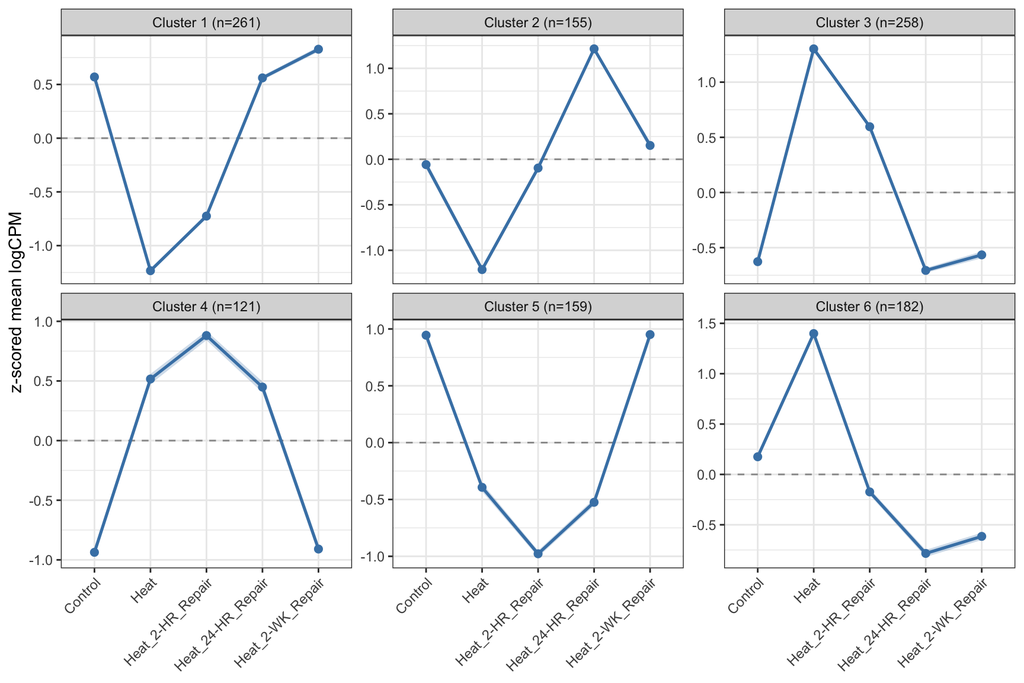

```r
km <- stats::kmeans(grp_z, centers = CONFIG$n_clusters,
                    nstart = 50, iter.max = 100)

clust_df <- do.call(rbind, lapply(seq_len(CONFIG$n_clusters), function(k) {
  m  <- grp_z[km$cluster == k, , drop = FALSE]
  se <- if (nrow(m) > 1) {
    apply(m, 2, function(v) stats::sd(v) / sqrt(length(v)))
  } else {
    rep(0, ncol(m))          # single-gene cluster: no spread to show
  }
  data.frame(
    Treatment = factor(CONFIG$treat_labels[colnames(grp_z)],
                       levels = CONFIG$treat_labels),
    Mean      = colMeans(m),
    SE        = se,
    Cluster   = paste0("Cluster ", k, " (n=", nrow(m), ")")
  )
}))

p_clust <- ggplot2::ggplot(clust_df, ggplot2::aes(Treatment, Mean, group = 1)) +
  ggplot2::geom_hline(yintercept = 0, linetype = 2, colour = "grey60") +
  ggplot2::geom_ribbon(ggplot2::aes(ymin = Mean - SE, ymax = Mean + SE),
                       fill = "steelblue", alpha = 0.25) +
  ggplot2::geom_line(colour = "steelblue", linewidth = 0.9) +
  ggplot2::geom_point(colour = "steelblue", size = 2) +
  ggplot2::facet_wrap(~ Cluster, scales = "free_y") +
  ggplot2::labs(x = NULL, y = "z-scored mean logCPM") +
  ggplot2::theme_bw() +
  ggplot2::theme(axis.text.x = ggplot2::element_text(angle = 45, hjust = 1))
p_clust
```

```r
ggplot2::ggsave(file.path(CONFIG$out_dir, "Trajectory_clusters.png"),
                p_clust, width = 9, height = 6, dpi = 300)
```

# Outputs

```r
out <- data.frame(
  GeneID        = rownames(res_spline),
  Symbol        = sub("^gene-([^|]+)\\|.*$", "\\1", rownames(res_spline)),
  logCPM        = res_spline$logCPM,
  PValue_spline = res_spline$PValue,
  FDR_spline    = res_spline$FDR,
  FDR_factor    = res_grp[rownames(res_spline), "FDR"],
  step_tab,
  Cluster       = unname(km$cluster[rownames(res_spline)]),
  row.names = NULL, check.names = FALSE
)
out <- out[order(out$FDR_spline), ]

utils::write.csv(out,
                 file.path(CONFIG$out_dir, "Timeseries_spline_results.csv"),
                 row.names = FALSE)

grp_means_out <- as.data.frame(grp_means)
colnames(grp_means_out) <- CONFIG$treat_labels[colnames(grp_means_out)]
utils::write.csv(grp_means_out,
                 file.path(CONFIG$out_dir, "Sig_gene_group_means_logCPM.csv"))

## Per-cluster gene lists for downstream GSEA/GO (feed into Script 7)
for (k in seq_len(CONFIG$n_clusters)) {
  utils::write.csv(out[which(out$Cluster == k), c("GeneID", "Symbol")],
                   file.path(CONFIG$out_dir, paste0("Cluster_", k, "_genes.csv")),
                   row.names = FALSE)
}
```